# Homework 1 - Data Analytics

Costanza Colauzzi, Gabriele Granzotto, Davide Zorzetto

2023-05-19

## Introduzione

Il dataset $\texttt{insurance.csv}$ descrive le spese mediche sostenute da una compagnia assicurativa statunitense per 1338 soggetti. Le variabili presenti nel dataset sono:

- $\texttt{age}$: età dell’assicurato
- $\texttt{sex}$: genere dell’assicurato
- $\texttt{bmi}$: indice di massa corporea
- $\texttt{children}$: numero di figli a carico
- $\texttt{smoker}$: fumatore
- $\texttt{region}$: l’area di residenza dell’assicurato negli Stati Uniti
- $\texttt{charges}$: le spese mediche individuali fatturate dall’assicurazione.

Per la creazione dei grafici è stata usata sia la libreria base, sia *“lattice”*.

### a.

Nel Dataset sono presenti *quattro* variabili categoriali:

- **Sex**
- **Children**
- **Smoker**
- **Region**

Sono state rappresentate attraverso dei **Barplot** che evidenziassero la *frequenza relativa*.  
Il valore più frequente è stato evidenziato con un **bordo rosso**.

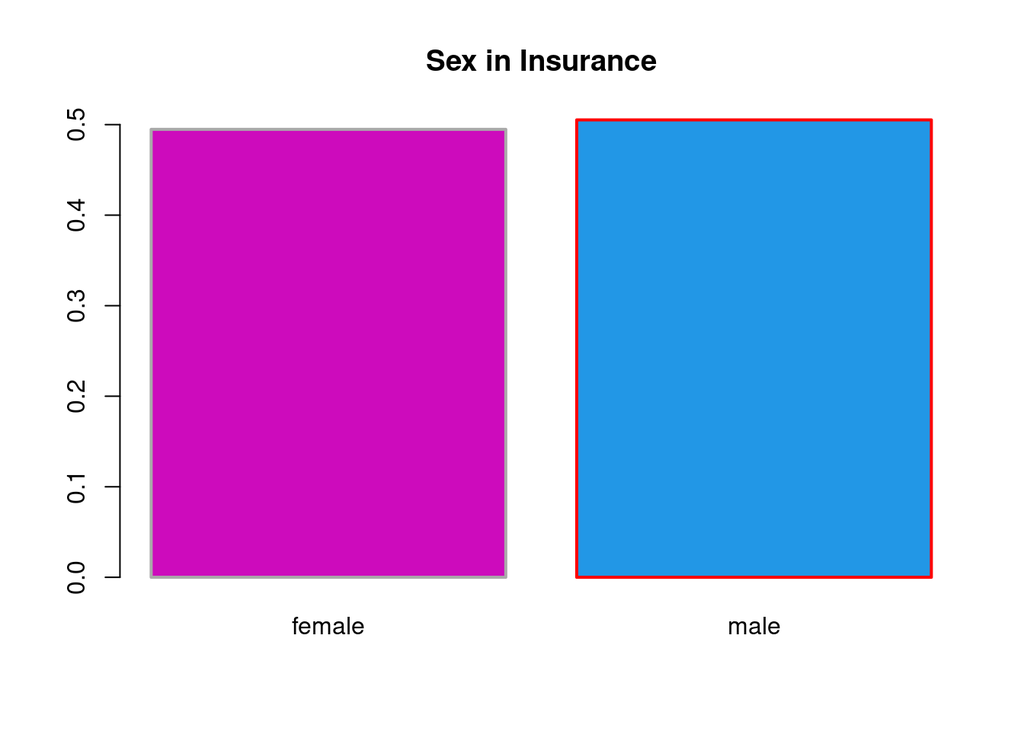

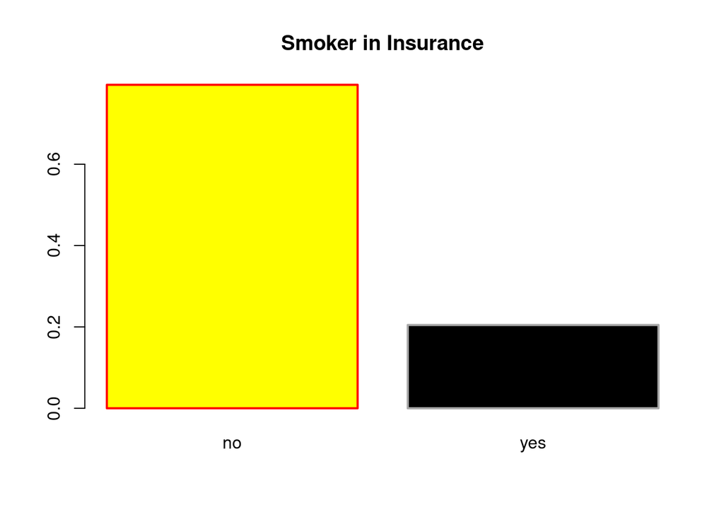

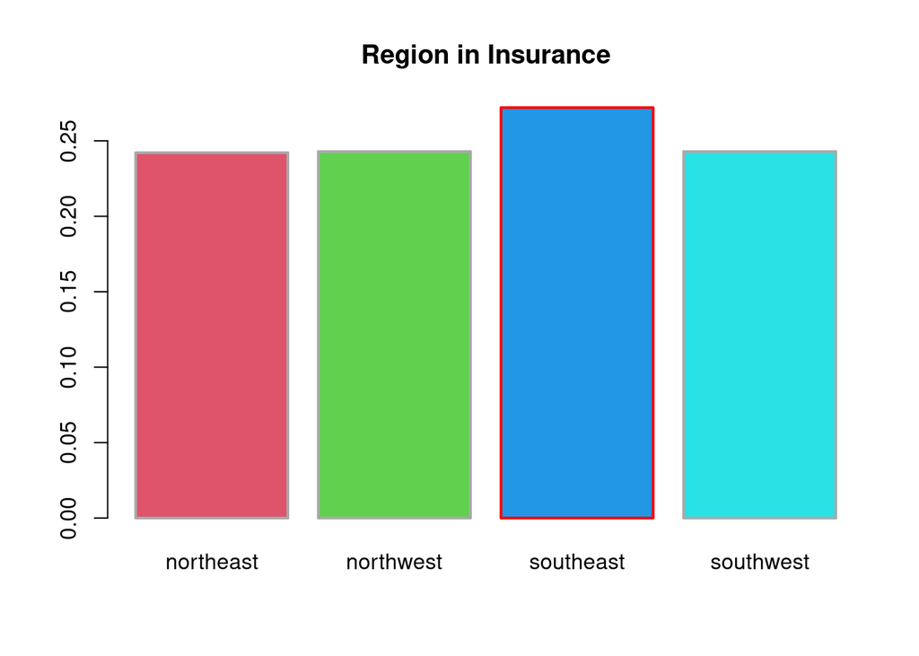

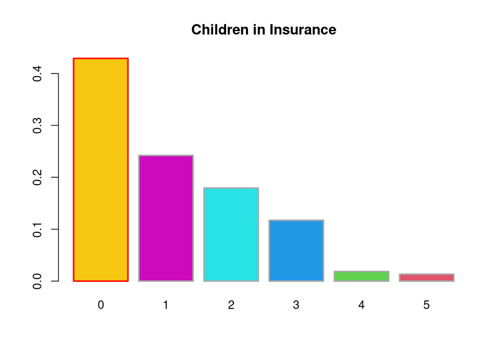

L’ultimo grafico rappresenta il numero di figli per individuo trattando la variabile figli come categoria.  
Pur essendo il numero di figli una variabile numerica abbiamo considerato ragionevole trattarle come variabili categoriali in quanto il numero delle categorie è limitato.

### b.

Nel grafico **Boxplot** sono state rappresentate le spese mediche rispetto al numero di figli divisi in *quattro* categorie:

- **0**
- **1**
- **2**
- **3+**

Al *Boxplot* sono state inserite delle **barre rosse** per indicare la **media** della distribuzione.

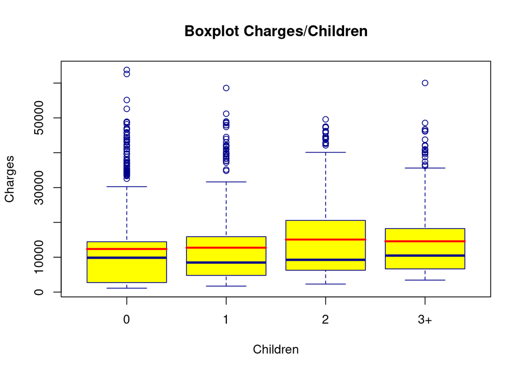

Si nota che la **media** ha valori superiori della **mediana** in quanto sono presenti numerosi valori oltre al baffo superiore del *boxplot*.  
Questo rende la distribuzione asimmetrica con una coda lunga verso i valori elevati di **Charges**.

### c.

A partire dalla variabile **bmi** è stata aggiunta una nuova variabile **catbmi** che utilizza le seguenti categorie:

- **underweight** : bmi $<$ 18.5
- **normal** : 18.5 $\leq$ bmi $\leq$ 24.99
- **overweight** : 25 $\leq$ bmi $<$ 30
- **obese** : bmi $\geq$ 30

Il grafico è stato prodotto con la libreria *“lattice”*.  
Dopo un’analisi l’Istogramma è stato diviso in *sei* blocchi, considerati sufficienti per rappresentare i dati.

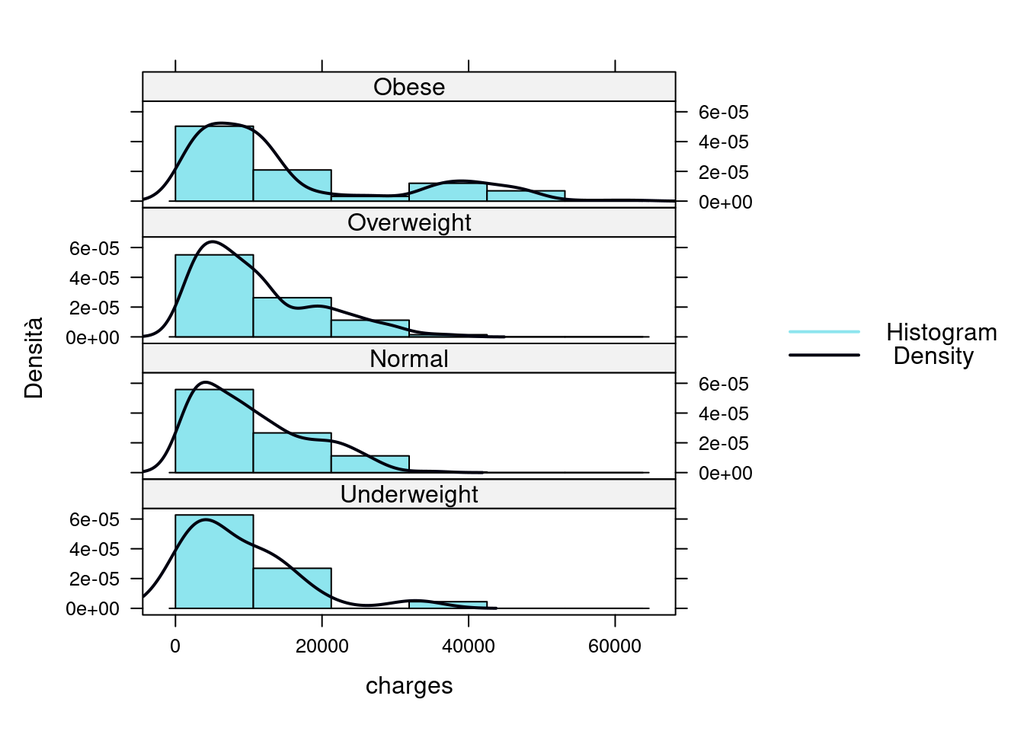

### d.

Come primo grafico per tentare di esplorare la relazione tra **catbmi** e **sex** sono stati usati due **Barplot Affiancati** delle *frequenze relative* di **sex** condizionato a **catbmi**.

```
##
##          Underweight Normal Overweight Obese
##   female          13    118        197   334
##   male             8    108        189   371
```

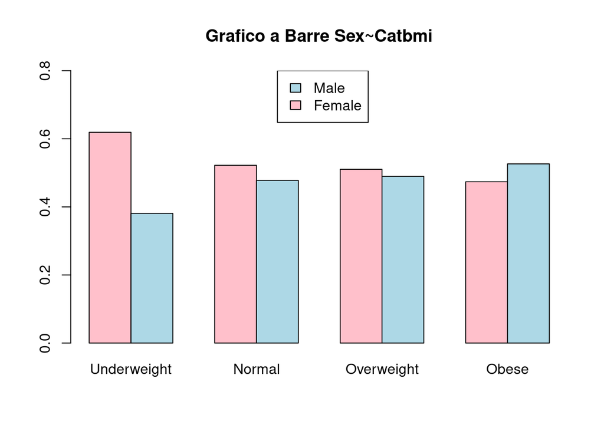

Da questo grafico si osserva che, tranne che nel gruppo dei *Underweight*, c’è una possibile indipendenza tra *maschi* e *femmine*.  
Abbiamo cercato di indagare sulla presunta differenza tra *maschi* e *femmine* negli *Underweight* quindi abbiamo disegnato il grafico delle *frequenze relative* di **catbmi** condizionato a **sex**.

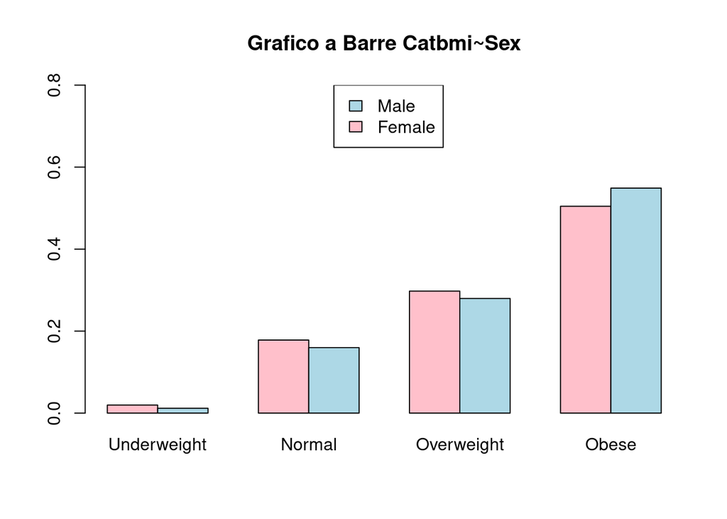

Questo grafico mostra lo scarso numero di dati della categoria *Underweight* per entrambi i generi.  
Se si vede la differenza dei valori tra *maschi* e *femmine* in un **Barplot** sembrerebbe suggerire che le donne sono più propense ad essere sottopeso.

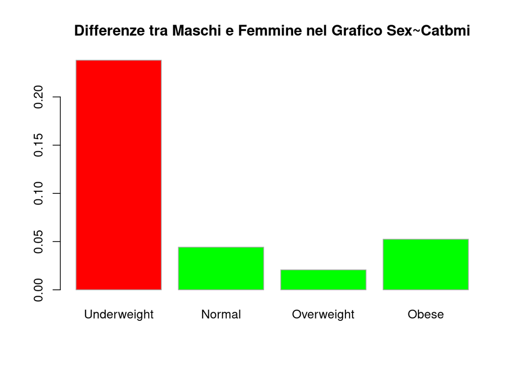

Ma questo dai dati che abbiamo non può essere evinto con certezza, poiché, come possiamo notare dal grafico sottostante, i dati relativi alla categoria **Underweight** a nostra disposizione sono in numero ridotto.

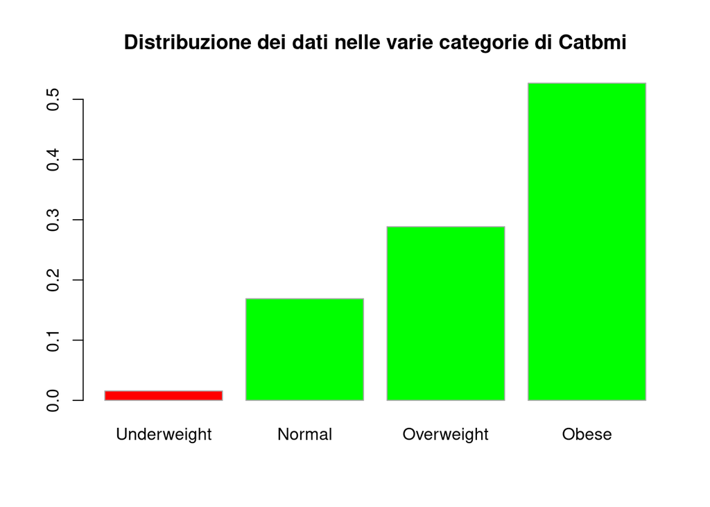

Infine, il test del $\chi^2$ mostra come ci sia poca evidenza contro l’ipotesi che le variabili *sesso* e *bmi* siano indipendenti, rendendo improbabile la loro associazione.

```
##
##  Pearson's Chi-squared test
##
## data:  table.sex.bmi
## X-squared = 3.5945, df = 3, p-value = 0.3087
```

### e.

L’immagine sottostante è composta da *cinque* grafici:

- Quello centrale è il **Grafico a Dispersione** delle spese mediche rapportate con l’età, in **verde** i non fumatori mentre in **viola** i fumatori;
- Sono presenti due **Boxplot** che rappresentano la distribuzione marginale delle *Spese Mediche* e *Età del Campione*;
- Vi sono anche due **Distribuzioni con il Metodo del Nucleo** di *Età* e *Spese Mediche* condizionatamente alla condizione *Fumatore*.

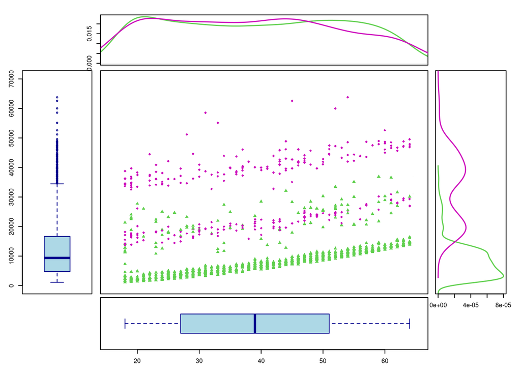